# Risk Factor Analysis

## Outcome Variable

**Outcome Variable:** y_rate_haz

## Predictor Variables

**Intervention Variable:** gagebrth

**Adjustment Set:**

unadjusted

## Stratifying Variables

The analysis was stratified on these variable(s):

- agecat
- studyid
- country

## Data Summary

| agecat | studyid | country | gagebrth | n_cell | n |
| --- | --- | --- | --- | --- | --- |
| 0-3 months | ki1000108-CMC-V-BCS-2002 | INDIA | Full or late term | 53 | 86 |
| 0-3 months | ki1000108-CMC-V-BCS-2002 | INDIA | Preterm | 11 | 86 |
| 0-3 months | ki1000108-CMC-V-BCS-2002 | INDIA | Early term | 22 | 86 |
| 0-3 months | ki1000108-IRC | INDIA | Full or late term | 230 | 359 |
| 0-3 months | ki1000108-IRC | INDIA | Preterm | 36 | 359 |
| 0-3 months | ki1000108-IRC | INDIA | Early term | 93 | 359 |
| 0-3 months | ki1000109-EE | PAKISTAN | Full or late term | 40 | 594 |
| 0-3 months | ki1000109-EE | PAKISTAN | Preterm | 384 | 594 |
| 0-3 months | ki1000109-EE | PAKISTAN | Early term | 170 | 594 |
| 0-3 months | ki1000304b-SAS-CompFeed | INDIA | Full or late term | 19 | 1161 |
| 0-3 months | ki1000304b-SAS-CompFeed | INDIA | Preterm | 1061 | 1161 |
| 0-3 months | ki1000304b-SAS-CompFeed | INDIA | Early term | 81 | 1161 |
| 0-3 months | ki1017093c-NIH-Crypto | BANGLADESH | Full or late term | 162 | 720 |
| 0-3 months | ki1017093c-NIH-Crypto | BANGLADESH | Preterm | 252 | 720 |
| 0-3 months | ki1017093c-NIH-Crypto | BANGLADESH | Early term | 306 | 720 |
| 0-3 months | ki1101329-Keneba | GAMBIA | Full or late term | 598 | 1232 |
| 0-3 months | ki1101329-Keneba | GAMBIA | Preterm | 183 | 1232 |
| 0-3 months | ki1101329-Keneba | GAMBIA | Early term | 451 | 1232 |
| 0-3 months | ki1119695-PROBIT | BELARUS | Full or late term | 6507 | 12745 |
| 0-3 months | ki1119695-PROBIT | BELARUS | Preterm | 432 | 12745 |
| 0-3 months | ki1119695-PROBIT | BELARUS | Early term | 5806 | 12745 |
| 0-3 months | ki1135781-COHORTS | GUATEMALA | Full or late term | 304 | 551 |
| 0-3 months | ki1135781-COHORTS | GUATEMALA | Preterm | 87 | 551 |
| 0-3 months | ki1135781-COHORTS | GUATEMALA | Early term | 160 | 551 |
| 0-3 months | ki1135781-COHORTS | INDIA | Full or late term | 561 | 1274 |
| 0-3 months | ki1135781-COHORTS | INDIA | Preterm | 279 | 1274 |
| 0-3 months | ki1135781-COHORTS | INDIA | Early term | 434 | 1274 |
| 0-3 months | kiGH5241-JiVitA-3 | BANGLADESH | Full or late term | 17560 | 33724 |
| 0-3 months | kiGH5241-JiVitA-3 | BANGLADESH | Preterm | 6740 | 33724 |
| 0-3 months | kiGH5241-JiVitA-3 | BANGLADESH | Early term | 9424 | 33724 |

[output cut: 99 more lines]

The following strata were considered:

- agecat: 0-3 months, studyid: ki1000108-CMC-V-BCS-2002, country: INDIA
- agecat: 0-3 months, studyid: ki1000108-IRC, country: INDIA
- agecat: 0-3 months, studyid: ki1000109-EE, country: PAKISTAN
- agecat: 0-3 months, studyid: ki1000304b-SAS-CompFeed, country: INDIA
- agecat: 0-3 months, studyid: ki1017093c-NIH-Crypto, country: BANGLADESH
- agecat: 0-3 months, studyid: ki1101329-Keneba, country: GAMBIA
- agecat: 0-3 months, studyid: ki1119695-PROBIT, country: BELARUS
- agecat: 0-3 months, studyid: ki1135781-COHORTS, country: GUATEMALA
- agecat: 0-3 months, studyid: ki1135781-COHORTS, country: INDIA
- agecat: 0-3 months, studyid: kiGH5241-JiVitA-3, country: BANGLADESH
- agecat: 12-24 months, studyid: ki1000108-CMC-V-BCS-2002, country: INDIA
- agecat: 12-24 months, studyid: ki1000108-IRC, country: INDIA
- agecat: 12-24 months, studyid: ki1017093c-NIH-Crypto, country: BANGLADESH
- agecat: 12-24 months, studyid: ki1066203-TanzaniaChild2, country: TANZANIA, UNITED REPUBLIC OF
- agecat: 12-24 months, studyid: ki1101329-Keneba, country: GAMBIA
- agecat: 12-24 months, studyid: ki1119695-PROBIT, country: BELARUS
- agecat: 12-24 months, studyid: ki1135781-COHORTS, country: GUATEMALA
- agecat: 12-24 months, studyid: ki1135781-COHORTS, country: INDIA
- agecat: 12-24 months, studyid: ki1135781-COHORTS, country: PHILIPPINES
- agecat: 12-24 months, studyid: kiGH5241-JiVitA-3, country: BANGLADESH
- agecat: 3-6 months, studyid: ki1000108-CMC-V-BCS-2002, country: INDIA
- agecat: 3-6 months, studyid: ki1000108-IRC, country: INDIA
- agecat: 3-6 months, studyid: ki1000109-EE, country: PAKISTAN
- agecat: 3-6 months, studyid: ki1000304b-SAS-CompFeed, country: INDIA
- agecat: 3-6 months, studyid: ki1017093c-NIH-Crypto, country: BANGLADESH
- agecat: 3-6 months, studyid: ki1066203-TanzaniaChild2, country: TANZANIA, UNITED REPUBLIC OF
- agecat: 3-6 months, studyid: ki1101329-Keneba, country: GAMBIA
- agecat: 3-6 months, studyid: ki1119695-PROBIT, country: BELARUS
- agecat: 3-6 months, studyid: ki1135781-COHORTS, country: GUATEMALA
- agecat: 3-6 months, studyid: ki1135781-COHORTS, country: INDIA
- agecat: 3-6 months, studyid: kiGH5241-JiVitA-3, country: BANGLADESH
- agecat: 6-12 months, studyid: ki1000108-CMC-V-BCS-2002, country: INDIA
- agecat: 6-12 months, studyid: ki1000108-IRC, country: INDIA
- agecat: 6-12 months, studyid: ki1000109-EE, country: PAKISTAN
- agecat: 6-12 months, studyid: ki1000304b-SAS-CompFeed, country: INDIA
- agecat: 6-12 months, studyid: ki1017093c-NIH-Crypto, country: BANGLADESH
- agecat: 6-12 months, studyid: ki1066203-TanzaniaChild2, country: TANZANIA, UNITED REPUBLIC OF
- agecat: 6-12 months, studyid: ki1101329-Keneba, country: GAMBIA
- agecat: 6-12 months, studyid: ki1119695-PROBIT, country: BELARUS
- agecat: 6-12 months, studyid: ki1135781-COHORTS, country: GUATEMALA
- agecat: 6-12 months, studyid: ki1135781-COHORTS, country: INDIA
- agecat: 6-12 months, studyid: ki1135781-COHORTS, country: PHILIPPINES
- agecat: 6-12 months, studyid: kiGH5241-JiVitA-3, country: BANGLADESH

### Dropped Strata

Some strata were dropped due to rare outcomes:

- agecat: 6-12 months, studyid: ki1000109-EE, country: PAKISTAN
- agecat: 12-24 months, studyid: ki1066203-TanzaniaChild2, country: TANZANIA, UNITED REPUBLIC OF

## Methods Detail

We’re interested in the causal parameters $E[Y_a]$ for all values of $a \in \mathcal{A}$. These parameters represent the mean outcome if, possibly contrary to fact, we intervened to set all units to have $A=a$. Under the randomization and positivity assumptions, these are identified by the statistical parameters $\psi_a=E_W[E_{Y|A,W}(Y|A=a,W)]$. In addition, we’re interested in the mean of $Y$, $E[Y]$ under no intervention (the observed mean). We will estimate these parameters by using SuperLearner to fit the relevant likelihood factors – $E_{Y|A,W}(Y|A=a,W)$ and $p(A=a|W)$, and then updating our likelihood fit using a joint TMLE.

For unadjusted analyses ($W=\{\}$), initial likelihoods were estimated using Lrnr_glm to estimate the simple $E(Y|A)$ and Lrnr_mean to estimate $p(A)$. For adjusted analyses, a small library containing Lrnr_glmnet, Lrnr_xgboost, and Lrnr_mean was used.

Having estimated these parameters, we will then use the delta method to estimate relative risks and attributable risks relative to a prespecified baseline level of $A$.

# Results Detail

## Results Plots

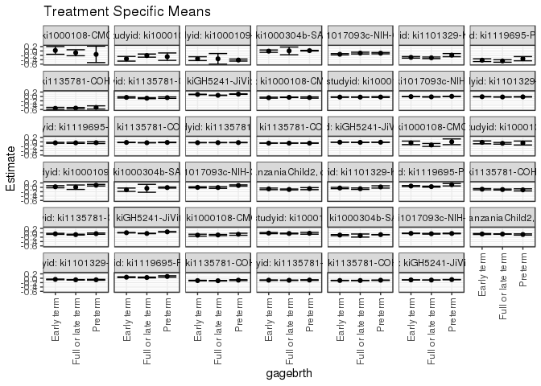

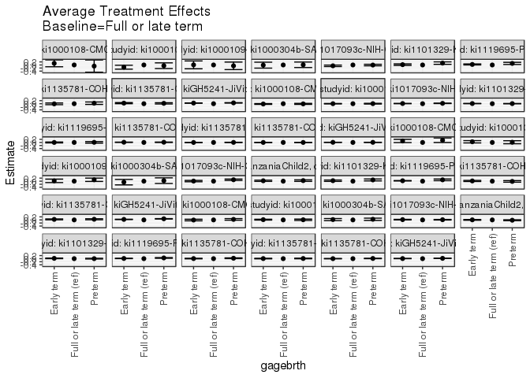

## Results Table

### Parameter: TSM

| agecat | studyid | country | intervention_level | baseline_level | estimate | ci_lower | ci_upper |
| --- | --- | --- | --- | --- | --- | --- | --- |
| 0-3 months | ki1000108-CMC-V-BCS-2002 | INDIA | Full or late term | NA | -0.0821329 | -0.2176995 | 0.0534337 |
| 0-3 months | ki1000108-CMC-V-BCS-2002 | INDIA | Preterm | NA | -0.1566869 | -0.5326169 | 0.2192430 |
| 0-3 months | ki1000108-CMC-V-BCS-2002 | INDIA | Early term | NA | 0.0238298 | -0.1533574 | 0.2010170 |
| 0-3 months | ki1000108-IRC | INDIA | Full or late term | NA | -0.2127493 | -0.2850034 | -0.1404953 |
| 0-3 months | ki1000108-IRC | INDIA | Preterm | NA | -0.2613060 | -0.4309995 | -0.0916126 |
| 0-3 months | ki1000108-IRC | INDIA | Early term | NA | -0.3580275 | -0.4642409 | -0.2518142 |
| 0-3 months | ki1000109-EE | PAKISTAN | Full or late term | NA | -0.3601538 | -0.6013733 | -0.1189342 |
| 0-3 months | ki1000109-EE | PAKISTAN | Preterm | NA | -0.4156357 | -0.4624867 | -0.3687847 |
| 0-3 months | ki1000109-EE | PAKISTAN | Early term | NA | -0.3525742 | -0.4397938 | -0.2653545 |
| 0-3 months | ki1000304b-SAS-CompFeed | INDIA | Full or late term | NA | 0.0027806 | -0.1743668 | 0.1799280 |
| 0-3 months | ki1000304b-SAS-CompFeed | INDIA | Preterm | NA | 0.0142596 | -0.0018747 | 0.0303939 |
| 0-3 months | ki1000304b-SAS-CompFeed | INDIA | Early term | NA | -0.0096085 | -0.0634321 | 0.0442151 |
| 0-3 months | ki1017093c-NIH-Crypto | BANGLADESH | Full or late term | NA | -0.0971370 | -0.1369681 | -0.0573059 |
| 0-3 months | ki1017093c-NIH-Crypto | BANGLADESH | Preterm | NA | -0.1020033 | -0.1318744 | -0.0721321 |
| 0-3 months | ki1017093c-NIH-Crypto | BANGLADESH | Early term | NA | -0.1518238 | -0.1794534 | -0.1241942 |
| 0-3 months | ki1101329-Keneba | GAMBIA | Full or late term | NA | -0.3123819 | -0.3474041 | -0.2773597 |
| 0-3 months | ki1101329-Keneba | GAMBIA | Preterm | NA | -0.1913191 | -0.2631621 | -0.1194761 |
| 0-3 months | ki1101329-Keneba | GAMBIA | Early term | NA | -0.2921173 | -0.3267514 | -0.2574832 |
| 0-3 months | ki1119695-PROBIT | BELARUS | Full or late term | NA | -0.4566790 | -0.5146360 | -0.3987221 |
| 0-3 months | ki1119695-PROBIT | BELARUS | Preterm | NA | -0.3548120 | -0.4510534 | -0.2585707 |
| 0-3 months | ki1119695-PROBIT | BELARUS | Early term | NA | -0.4223553 | -0.4860328 | -0.3586778 |
| 0-3 months | ki1135781-COHORTS | GUATEMALA | Full or late term | NA | -0.5371614 | -0.5695101 | -0.5048126 |
| 0-3 months | ki1135781-COHORTS | GUATEMALA | Preterm | NA | -0.5043657 | -0.5766624 | -0.4320691 |
| 0-3 months | ki1135781-COHORTS | GUATEMALA | Early term | NA | -0.5473697 | -0.5930561 | -0.5016832 |
| 0-3 months | ki1135781-COHORTS | INDIA | Full or late term | NA | -0.0807919 | -0.1040956 | -0.0574883 |
| 0-3 months | ki1135781-COHORTS | INDIA | Preterm | NA | -0.0566422 | -0.0908294 | -0.0224549 |
| 0-3 months | ki1135781-COHORTS | INDIA | Early term | NA | -0.0442623 | -0.0727161 | -0.0158085 |
| 0-3 months | kiGH5241-JiVitA-3 | BANGLADESH | Full or late term | NA | 0.0509284 | 0.0443099 | 0.0575469 |
| 0-3 months | kiGH5241-JiVitA-3 | BANGLADESH | Preterm | NA | 0.1054950 | 0.0944264 | 0.1165635 |
| 0-3 months | kiGH5241-JiVitA-3 | BANGLADESH | Early term | NA | 0.0916723 | 0.0824752 | 0.1008694 |

[output cut: 93 more lines]

### Parameter: E(Y)

| agecat | studyid | country | intervention_level | baseline_level | estimate | ci_lower | ci_upper |
| --- | --- | --- | --- | --- | --- | --- | --- |
| 0-3 months | ki1000108-CMC-V-BCS-2002 | INDIA | NA | NA | -0.0645622 | -0.1717754 | 0.0426511 |
| 0-3 months | ki1000108-IRC | INDIA | NA | NA | -0.2552533 | -0.3120978 | -0.1984087 |
| 0-3 months | ki1000109-EE | PAKISTAN | NA | NA | -0.3938516 | -0.4364614 | -0.3512419 |
| 0-3 months | ki1000304b-SAS-CompFeed | INDIA | NA | NA | 0.0124065 | -0.0035539 | 0.0283669 |
| 0-3 months | ki1017093c-NIH-Crypto | BANGLADESH | NA | NA | -0.1220821 | -0.1402761 | -0.1038881 |
| 0-3 months | ki1101329-Keneba | GAMBIA | NA | NA | -0.2869811 | -0.3108317 | -0.2631304 |
| 0-3 months | ki1119695-PROBIT | BELARUS | NA | NA | -0.4375900 | -0.4969173 | -0.3782626 |
| 0-3 months | ki1135781-COHORTS | GUATEMALA | NA | NA | -0.5349474 | -0.5599715 | -0.5099233 |
| 0-3 months | ki1135781-COHORTS | INDIA | NA | NA | -0.0630591 | -0.0790628 | -0.0470554 |
| 0-3 months | kiGH5241-JiVitA-3 | BANGLADESH | NA | NA | 0.0732196 | 0.0679849 | 0.0784544 |
| 3-6 months | ki1000108-CMC-V-BCS-2002 | INDIA | NA | NA | -0.0963982 | -0.1464314 | -0.0463649 |
| 3-6 months | ki1000108-IRC | INDIA | NA | NA | -0.0533200 | -0.0841764 | -0.0224636 |
| 3-6 months | ki1000109-EE | PAKISTAN | NA | NA | 0.0701161 | 0.0419135 | 0.0983187 |
| 3-6 months | ki1000304b-SAS-CompFeed | INDIA | NA | NA | -0.0183559 | -0.0366653 | -0.0000465 |
| 3-6 months | ki1017093c-NIH-Crypto | BANGLADESH | NA | NA | 0.0267740 | 0.0099602 | 0.0435879 |
| 3-6 months | ki1066203-TanzaniaChild2 | TANZANIA, UNITED REPUBLIC OF | NA | NA | -0.0857474 | -0.1027530 | -0.0687418 |
| 3-6 months | ki1101329-Keneba | GAMBIA | NA | NA | -0.0387574 | -0.0597399 | -0.0177750 |
| 3-6 months | ki1119695-PROBIT | BELARUS | NA | NA | 0.0470780 | 0.0278572 | 0.0662989 |
| 3-6 months | ki1135781-COHORTS | GUATEMALA | NA | NA | -0.0990042 | -0.1156213 | -0.0823871 |
| 3-6 months | ki1135781-COHORTS | INDIA | NA | NA | -0.0614636 | -0.0743514 | -0.0485759 |
| 3-6 months | kiGH5241-JiVitA-3 | BANGLADESH | NA | NA | -0.0072058 | -0.0128771 | -0.0015345 |
| 6-12 months | ki1000108-CMC-V-BCS-2002 | INDIA | NA | NA | -0.0976775 | -0.1183059 | -0.0770491 |
| 6-12 months | ki1000108-IRC | INDIA | NA | NA | -0.0262272 | -0.0395135 | -0.0129410 |
| 6-12 months | ki1000304b-SAS-CompFeed | INDIA | NA | NA | -0.0866765 | -0.0910798 | -0.0822732 |
| 6-12 months | ki1017093c-NIH-Crypto | BANGLADESH | NA | NA | -0.0315658 | -0.0388594 | -0.0242722 |
| 6-12 months | ki1066203-TanzaniaChild2 | TANZANIA, UNITED REPUBLIC OF | NA | NA | -0.0605003 | -0.0699708 | -0.0510298 |
| 6-12 months | ki1101329-Keneba | GAMBIA | NA | NA | -0.0633234 | -0.0720864 | -0.0545604 |
| 6-12 months | ki1119695-PROBIT | BELARUS | NA | NA | 0.0422873 | 0.0257506 | 0.0588239 |
| 6-12 months | ki1135781-COHORTS | GUATEMALA | NA | NA | -0.1074247 | -0.1156062 | -0.0992433 |
| 6-12 months | ki1135781-COHORTS | INDIA | NA | NA | -0.0891165 | -0.0967571 | -0.0814759 |
| 6-12 months | ki1135781-COHORTS | PHILIPPINES | NA | NA | -0.0997523 | -0.1048942 | -0.0946103 |
| 6-12 months | kiGH5241-JiVitA-3 | BANGLADESH | NA | NA | -0.0767730 | -0.0799829 | -0.0735630 |
| 12-24 months | ki1000108-CMC-V-BCS-2002 | INDIA | NA | NA | -0.0466658 | -0.0572396 | -0.0360921 |
| 12-24 months | ki1000108-IRC | INDIA | NA | NA | -0.0317691 | -0.0390870 | -0.0244512 |
| 12-24 months | ki1017093c-NIH-Crypto | BANGLADESH | NA | NA | -0.0057326 | -0.0097260 | -0.0017391 |
| 12-24 months | ki1101329-Keneba | GAMBIA | NA | NA | -0.0203627 | -0.0246735 | -0.0160519 |
| 12-24 months | ki1119695-PROBIT | BELARUS | NA | NA | -0.0430497 | -0.0603171 | -0.0257823 |
| 12-24 months | ki1135781-COHORTS | GUATEMALA | NA | NA | -0.0331016 | -0.0373272 | -0.0288759 |
| 12-24 months | ki1135781-COHORTS | INDIA | NA | NA | -0.0339532 | -0.0372308 | -0.0306756 |
| 12-24 months | ki1135781-COHORTS | PHILIPPINES | NA | NA | -0.0576585 | -0.0601967 | -0.0551203 |
| 12-24 months | kiGH5241-JiVitA-3 | BANGLADESH | NA | NA | -0.0193495 | -0.0213977 | -0.0173013 |

### Parameter: ATE

| agecat | studyid | country | intervention_level | baseline_level | estimate | ci_lower | ci_upper |
| --- | --- | --- | --- | --- | --- | --- | --- |
| 0-3 months | ki1000108-CMC-V-BCS-2002 | INDIA | Full or late term | Full or late term | 0.0000000 | 0.0000000 | 0.0000000 |
| 0-3 months | ki1000108-CMC-V-BCS-2002 | INDIA | Preterm | Full or late term | -0.0745540 | -0.4741809 | 0.3250728 |
| 0-3 months | ki1000108-CMC-V-BCS-2002 | INDIA | Early term | Full or late term | 0.1059627 | -0.1171373 | 0.3290627 |
| 0-3 months | ki1000108-IRC | INDIA | Full or late term | Full or late term | 0.0000000 | 0.0000000 | 0.0000000 |
| 0-3 months | ki1000108-IRC | INDIA | Preterm | Full or late term | -0.0485567 | -0.2329924 | 0.1358789 |
| 0-3 months | ki1000108-IRC | INDIA | Early term | Full or late term | -0.1452782 | -0.2737380 | -0.0168184 |
| 0-3 months | ki1000109-EE | PAKISTAN | Full or late term | Full or late term | 0.0000000 | 0.0000000 | 0.0000000 |
| 0-3 months | ki1000109-EE | PAKISTAN | Preterm | Full or late term | -0.0554819 | -0.3012092 | 0.1902453 |
| 0-3 months | ki1000109-EE | PAKISTAN | Early term | Full or late term | 0.0075796 | -0.2489241 | 0.2640833 |
| 0-3 months | ki1000304b-SAS-CompFeed | INDIA | Full or late term | Full or late term | 0.0000000 | 0.0000000 | 0.0000000 |
| 0-3 months | ki1000304b-SAS-CompFeed | INDIA | Preterm | Full or late term | 0.0114790 | -0.1689628 | 0.1919208 |
| 0-3 months | ki1000304b-SAS-CompFeed | INDIA | Early term | Full or late term | -0.0123890 | -0.2057453 | 0.1809673 |
| 0-3 months | ki1017093c-NIH-Crypto | BANGLADESH | Full or late term | Full or late term | 0.0000000 | 0.0000000 | 0.0000000 |
| 0-3 months | ki1017093c-NIH-Crypto | BANGLADESH | Preterm | Full or late term | -0.0048662 | -0.0546538 | 0.0449213 |
| 0-3 months | ki1017093c-NIH-Crypto | BANGLADESH | Early term | Full or late term | -0.0546868 | -0.1031627 | -0.0062109 |
| 0-3 months | ki1101329-Keneba | GAMBIA | Full or late term | Full or late term | 0.0000000 | 0.0000000 | 0.0000000 |
| 0-3 months | ki1101329-Keneba | GAMBIA | Preterm | Full or late term | 0.1210628 | 0.0411380 | 0.2009875 |
| 0-3 months | ki1101329-Keneba | GAMBIA | Early term | Full or late term | 0.0202646 | -0.0289906 | 0.0695198 |
| 0-3 months | ki1119695-PROBIT | BELARUS | Full or late term | Full or late term | 0.0000000 | 0.0000000 | 0.0000000 |
| 0-3 months | ki1119695-PROBIT | BELARUS | Preterm | Full or late term | 0.1018670 | 0.0306301 | 0.1731039 |
| 0-3 months | ki1119695-PROBIT | BELARUS | Early term | Full or late term | 0.0343238 | 0.0018311 | 0.0668165 |
| 0-3 months | ki1135781-COHORTS | GUATEMALA | Full or late term | Full or late term | 0.0000000 | 0.0000000 | 0.0000000 |
| 0-3 months | ki1135781-COHORTS | GUATEMALA | Preterm | Full or late term | 0.0327956 | -0.0464082 | 0.1119995 |
| 0-3 months | ki1135781-COHORTS | GUATEMALA | Early term | Full or late term | -0.0102083 | -0.0661877 | 0.0457711 |
| 0-3 months | ki1135781-COHORTS | INDIA | Full or late term | Full or late term | 0.0000000 | 0.0000000 | 0.0000000 |
| 0-3 months | ki1135781-COHORTS | INDIA | Preterm | Full or late term | 0.0241497 | -0.0172245 | 0.0655240 |
| 0-3 months | ki1135781-COHORTS | INDIA | Early term | Full or late term | 0.0365296 | -0.0002492 | 0.0733084 |
| 0-3 months | kiGH5241-JiVitA-3 | BANGLADESH | Full or late term | Full or late term | 0.0000000 | 0.0000000 | 0.0000000 |
| 0-3 months | kiGH5241-JiVitA-3 | BANGLADESH | Preterm | Full or late term | 0.0545666 | 0.0420553 | 0.0670778 |
| 0-3 months | kiGH5241-JiVitA-3 | BANGLADESH | Early term | Full or late term | 0.0407438 | 0.0301506 | 0.0513371 |

[output cut: 93 more lines]